# Valores Influyentes

Carlos Jara

5 de enero de 2019

# 1 - Cuarteto de Anscombe

Veamos los resultados de los graficos y las regresiones del denominado “Cuarteto de Anscombe”.

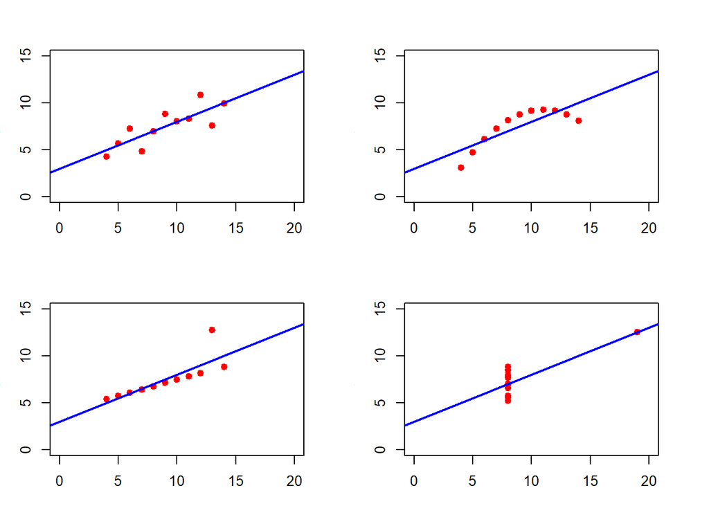

# 2 - Valores Atipicos

Un valor atipico es una observacion extrema. Los valores atipicos se deben investigar con muchisimo cuidado de modo de tratar de encontrar la razon de este comportamiento extraordinario. A veces los valores atipicos son malos debido a que origen esta en defectos de medicion, registro incorrecto o falla del instrumento de medicion. En caso que suceda esto, el valor atipico debe ser corregido o eliminado de entre los datos. La razon de esto es que, los valores atipicos, *tienden a llevar para si a la recta de regresion ya que esta generando residuos altos y el metodo MCO busca minimizarlos*. en otras oportunidades, los valores atipicos son solo una observacion factible pero extraordinaria. Los buenos valores atipicos permiten conocer el comportamiento de la estimacion en las regiones en las cuales se producen. Como conclusion, debemos tratar de identificar a estos valores y manejarlos con sumo cuidado en funcion a tratar de establecer la razon de la presencia del mismo.

El estudio de los valores atipicos se realiza *analizando el resultado obtenido por la medida, la cual se obtiene para cada observacion pero sin tener en cuenta a esta*, es decir, cual seria el resultado si quitaramos del analisis esa observacion en particular, *cuando la diferencia entre los resultados con y sin la observacion son grandes, se interpreta como que esa observacion es un valor atipico*.

## Matriz Hat o Leverage

La matriz H determina la varianza y la covarianza de los vectores estimados $\hat Y$ y del vector de residuales e. Los elementos de la diagonal principal $(h_{ii})$ de la matriz H pueden interpretarse como la influencia de Y sobre la estimacion $\hat Y$.

$$H=X(X?X)^{-1}X$$

## Distancia de Cook

//https:virtual.utpc.edu.co/ova/estadistica/docs/libros/2007315/lecciones_html/capitulo_6/leccion6/6-4/dffits.html

Se define la distancia de Cook como
$$D_{i}=[\frac{e_{i}}{\sqrt{s^2*(1-h_{ii})}}]^2*\frac{h_{ii}}{(1-h_{ii})*p}$$

- $e_{i}$= el residual i-esimo con los datos completos.
- $h_{ii}$ es el i-esimo elemento de la matriz Hat, siendo la matriz Hat=$X(X?X)^{-1}$.
- $S^2$=Cuadrado Medio de los errores (CME).
- p=Cantidad de variables (dependientes e independientes) en el modelo.

Si D > 1, el punto se considera influyente.

## Dffits

La estadistica DFFTIS *mide el numero de desvios estandar existente entre cada estimacion ($\hat{Y_{i}}$) y la misma estimacion Y si la observacion i-esima es eliminada.*
$$DFFITS_{i}=\frac{\hat{Y_{i}}-\hat{Y_{(i)}}}{\sqrt{s_{(i)}^2*h_{ii}}}$$
Si $\mid DFFTIS\mid>2*\sqrt{\frac{p}{n}}$ el valor es influyente.

## DfBetas

El DFBetas indica *cuanto cambia el coeficiente de la regresion $b_{i}$, en cantidad de desvios estandar, si la i-esima observacion es eliminada.*

$$DFBetas_{i,j}=\frac{b_{j}-b_{j,(i)}}{\sqrt{s_{(i)}^2*C_{jj}}}$$
Donde el denominador es la varianza del coeficiente de regresion $b_{j}$ calculada sin la i-esima observacion.

Si $\mid DFBetas_{i,j}\mid>\frac{2}{\sqrt{n}}$, entonces la observacion es influyente.

## CovRatio

El CovRatio utiliza la varianza generalizada del vector de estimaciones de los coeficientes b. Recordemos que la varianza de los estimadores esta dada por $V_{b}=s^2*(X?X)^{-1}$

$$CovRatio=\frac{s_{(i)}^2*(X_{(i)}?X_{(i)})^{-1}}{s^2*(X?X)^{-1}}$$
+ Si CovRatio > 1, la observacion mejora la precision de la estimacion y si CovRatio<1, la inclusion de la observacion disminuye la precision de la observacion. + Si $\mid CovRatio \mid > 1+3*\frac{p}{n}$, la observacion se considera influyente.

# 3 - Graficos para su deteccion

Basado en https://cran.r-proyect.org/web/packages/olsrr/vignettes/influence_measures.html

Basados en el paquete de R “olsrr”, veamos algunas graficas para la deteccion de valores influyentes.

Para esto vamos a tomar los datos de “TP 4 EJ 31”

Vemos los graficos

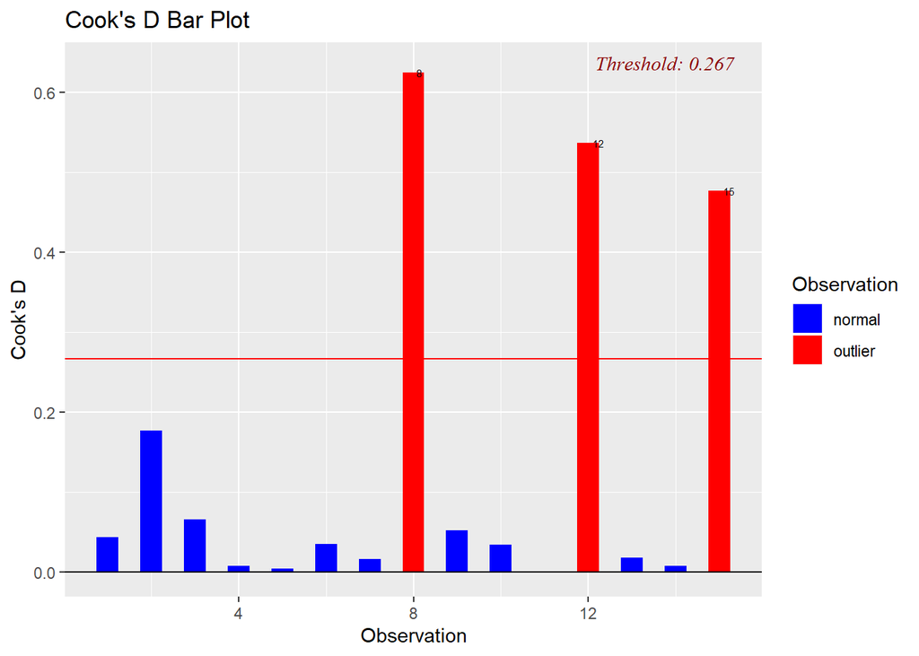

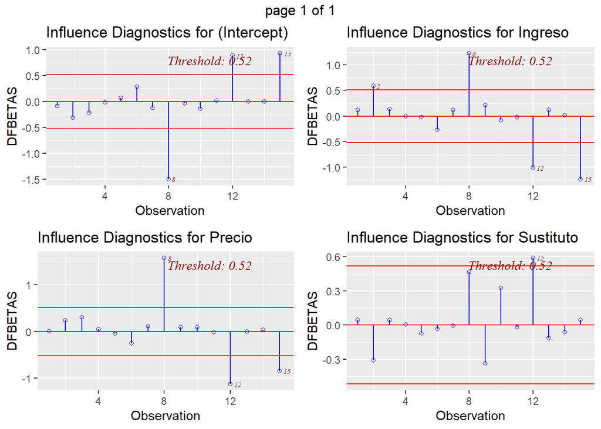

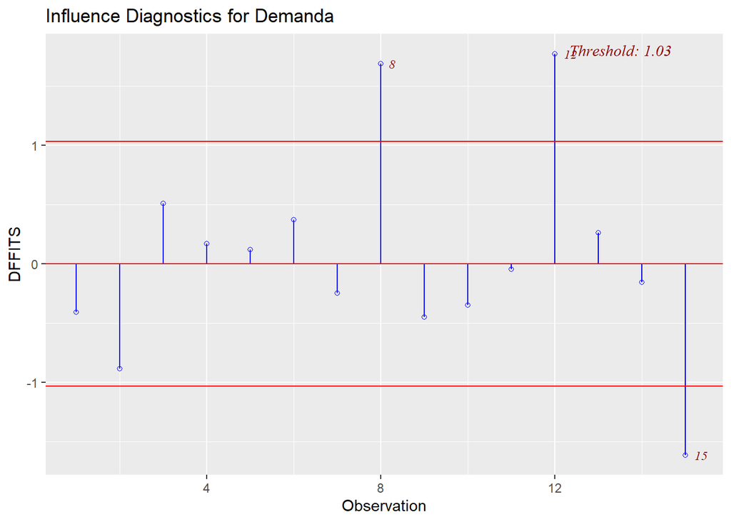

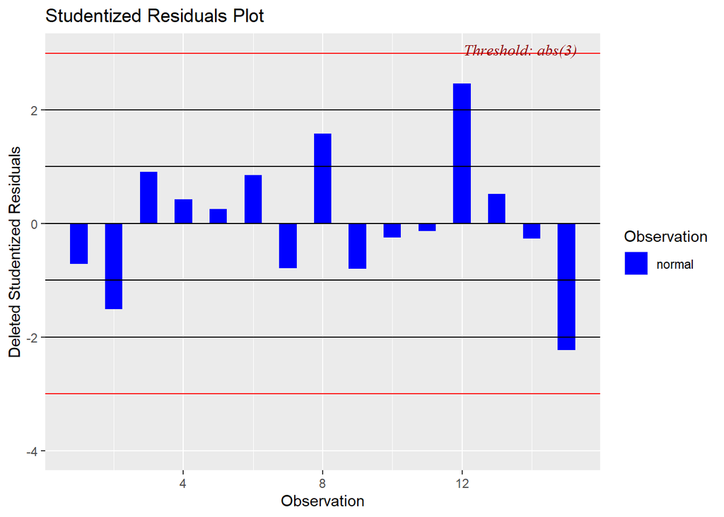

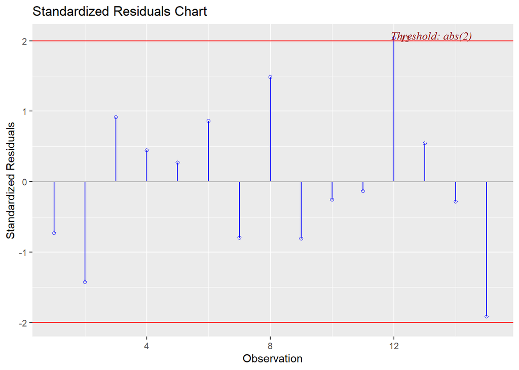

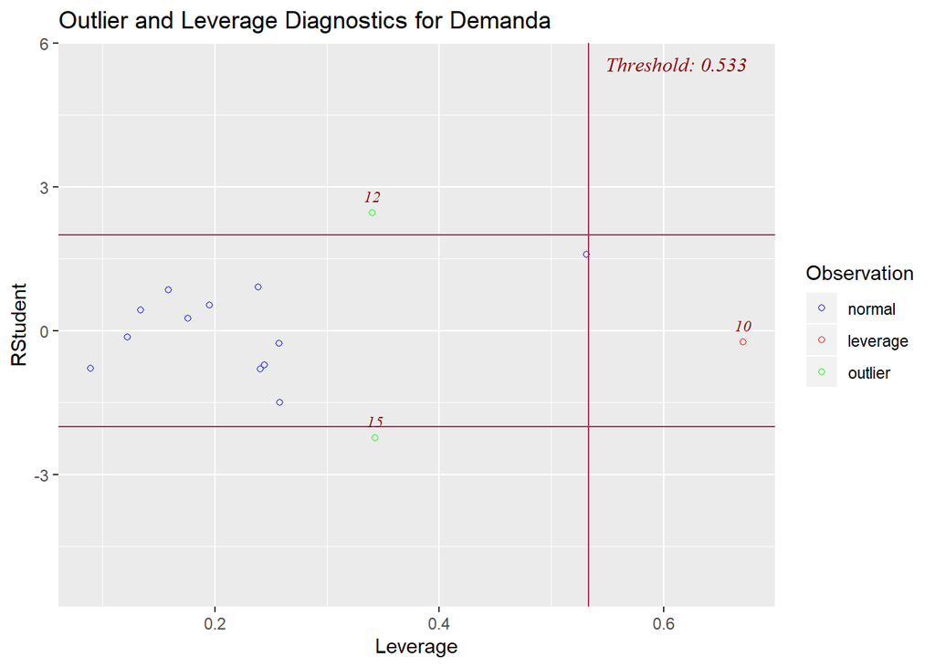

# 4 - Analisis de Residuos

Recordemos que los residuos deben ser normales con $\mu$=0 y $\sigma^2$=cte. Si tomamos los residuos estandarizados, $\sigma^2$=1.

Los supuestos mas fuertes del modelo de MCO estan asociados al comportamiento de los residuos, por lo tanto se hace necesario un analisis posterior de los mismos.

Veamos el histograma de los residuos

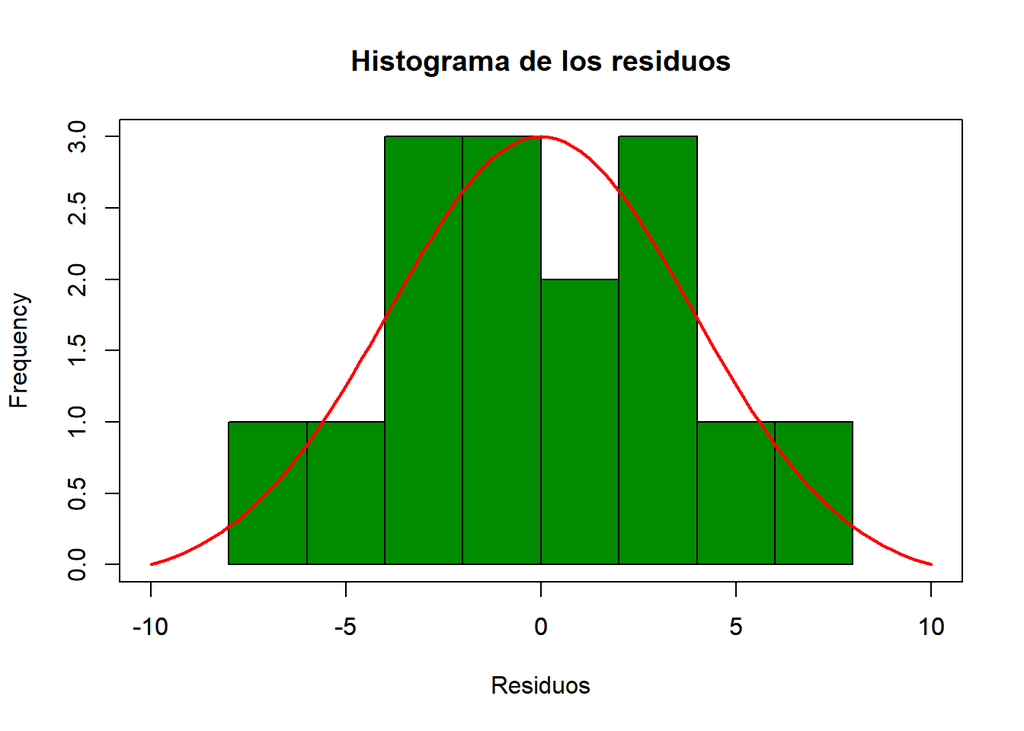

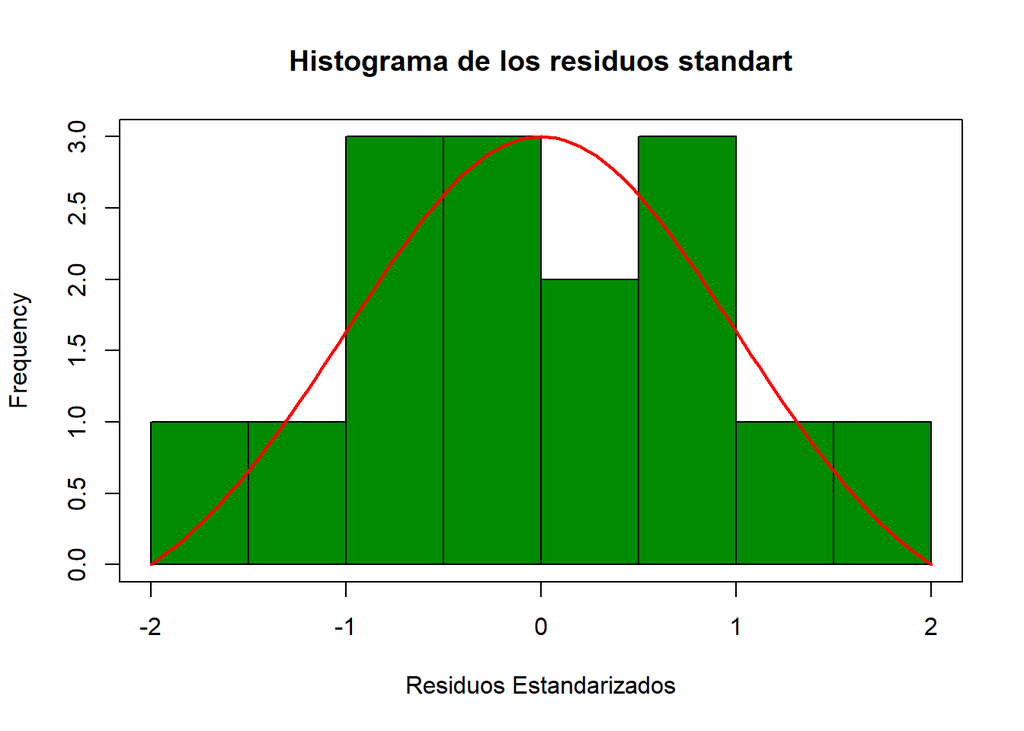

Con posterioridad al analisis grafico es posible realizar varios Test de Normalidad donde la H0 supone justamente que los datos analizados son normales.

Uno de los test mas utilizados es el de Shapiro-Wilks dado que es uno de los mas potentes, se utiliza fundamentalmente cuando el tama?o de la muestra es menor de 50.

```
##
##  Shapiro-Wilk normality test
##
## data:  a
## W = 0.98, p-value = 1
```

Otra opcion valido pero en este caso para muestras superiores a los 50 datos, es el Test de Kolmogorov-Smirnov (KS), este test puede ser utilizado para comparar dos distribuciones o realizar la comparacion de una distribucion empirica (en base a los datos) con cualquier distribucion teorica que se plantee, sea esta una distribucion o no.

Esto se debe a que el estadistico KS se basa en calcular las diferencias que existen entre la distribucion empirica y la teorica planteada, cuando estas diferencias superan determinado valor que esta tabulado, se dice que los datos no se ajustan a esa distribucion.

Para su analisis, ordena los datos de menor a mayor y compara cada uno con *el valor teorico de la distribucion asociada que deberia tener para esa observacion*.

```
##
##  One-sample Kolmogorov-Smirnov test
##
## data:  a
## D = 0.097, p-value = 1
## alternative hypothesis: two-sided
```

Utilizando la funcion “ols_test_normality” del paquete “olsrr” vemos los resultados de 4 diferentes test de normalidad.

```
## -----------------------------------------------
##        Test             Statistic       pvalue
## -----------------------------------------------
## Shapiro-Wilk              0.9846         0.9915
## Kolmogorov-Smirnov        0.0973         0.9961
## Cramer-von Mises          1.2667         0.0004
## Anderson-Darling          0.1451         0.9581
## -----------------------------------------------
```

https://stackoverflow.com/questions/45591286/for-r-markdown-how-do-i-display-a-matrix-from-r-variable